# Modern Portfolio Theory (MPT)

In this project, I apply Modern Portfolio Theory (MPT) to optimize investment portfolios based on historical asset performance. Developed by Harry Markowitz in 1952, MPT provides a mathematical framework for assembling a portfolio of assets such that the expected return is maximized for a given level of risk, or alternatively, risk is minimized for a given level of expected return.

By analyzing the historical returns and covariances between different assets, I aim to construct an efficient frontier — a set of optimal portfolios offering the highest expected return for a defined level of risk. The models are implemented in Python, leveraging libraries such as numpy, pandas, matplotlib, and scipy.optimize.

This approach highlights the core principle of diversification: combining assets that do not perfectly correlate to reduce overall portfolio volatility without sacrificing returns.

# Import the necessary libraries and Data

```python
import pandas as pd
import numpy as np
import matplotlib.pyplot as plt
!pip install -q yfinance
import yfinance as yf
import warnings
warnings.filterwarnings("ignore")
import scipy.optimize as sco
```

We will be working with 20 different assets, carefully selected by the author to align with the principle of diversification, ensuring a balanced representation across sectors and asset classes.

AAPL (Apple Inc.)

MSFT (Microsoft Corporation)

AMZN (Amazon.com, Inc.)

GOOG (Alphabet Inc. Class C)

META (Meta Platforms, Inc.)

TSLA (Tesla, Inc.)

JPM (JPMorgan Chase & Co.)

BAC (Bank of America Corporation)

V (Visa Inc.)

MA (Mastercard Incorporated)

XOM (Exxon Mobil Corporation)

CVX (Chevron Corporation)

VOO (S&P 500 ETF)

QQQ (Nasdaq 100 ETF)

IWM (Russell 2000 ETF)

GLD (SPDR Gold Trust)

TLT (iShares 20+ Year Treasury Bond ETF)

VNQ (Vanguard Real Estate ETF)

BRK.B (Berkshire Hathaway Inc.)

UNH (UnitedHealth Group Incorporated)

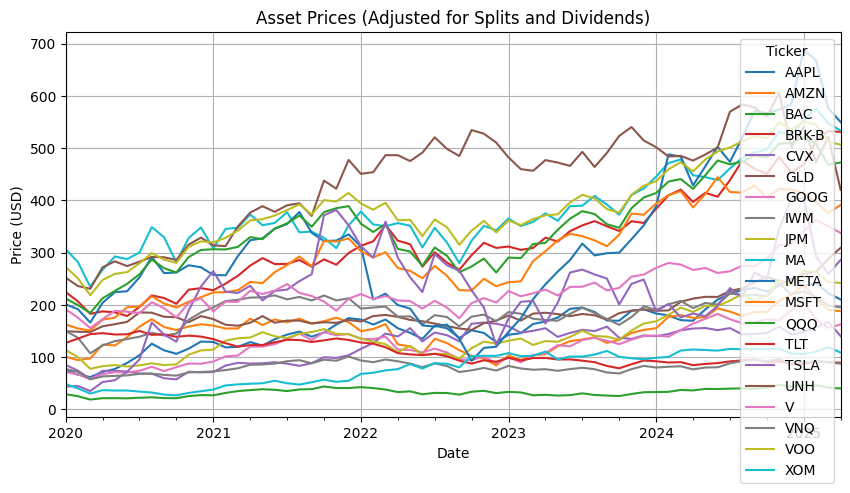

```python
# Parameters
start = "2020-01-01"
end = "2025-04-26"
frequency = "1mo"
assets = [
    "AAPL", "MSFT", "AMZN", "GOOG", "META", "TSLA",
    "JPM", "BAC", "V", "MA", "XOM", "CVX",
    "VOO", "QQQ", "IWM", "GLD", "TLT", "VNQ",
    "BRK-B", "UNH"
]

# Download data with auto-adjusted prices
prices = yf.download(
    tickers=assets,
    start=start,
    end=end,
    interval=frequency,
    auto_adjust=True,
    progress=False
)

# Keep only 'Close' prices
if isinstance(prices.columns, pd.MultiIndex):
    prices = prices['Close']

# Drop missing data
prices = prices.dropna()

# Plot
prices.plot(figsize=(10, 5), title="Asset Prices (Adjusted for Splits and Dividends)")
plt.xlabel("Date")
plt.ylabel("Price (USD)")
plt.grid(True)
plt.show()
```

```python
# Calculate log returns
returns = np.log(prices / prices.shift(1)).dropna()

# Calculate the expected annualized returns
mu = returns.mean() * 12  # 12 because we are using monthly data

# Display
print(round(mu, 4))
```

```
Ticker
AAPL     0.1964
AMZN     0.1191
BAC      0.0615
BRK-B    0.1640
CVX      0.0955
GLD      0.1386
GOOG     0.1566
IWM      0.0497
JPM      0.1444
MA       0.1058
META     0.1917
MSFT     0.1673
QQQ      0.1525
TLT     -0.0676
TSLA     0.3592
UNH      0.0972
V        0.1077
VNQ      0.0244
VOO      0.1179
XOM      0.1543
dtype: float64
```

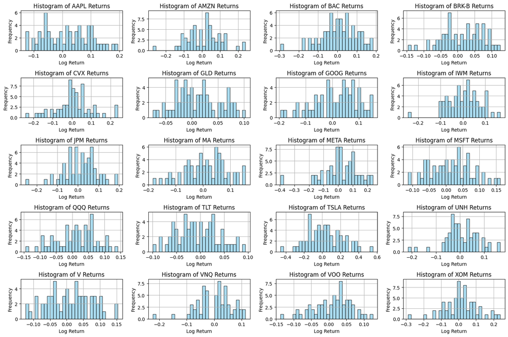

```python
# Plot histograms for all assets
fig, axes = plt.subplots(nrows=5, ncols=4, figsize=(15, 10))  # Adjust grid for 20 assets

# Flatten axes to easily loop through them
axes = axes.flatten()

# Loop through each asset and plot its histogram
for i, ticker in enumerate(returns.columns):
    axes[i].hist(returns[ticker], bins=30, alpha=0.7, color='skyblue', edgecolor='black')
    axes[i].set_title(f'Histogram of {ticker} Returns')
    axes[i].set_xlabel('Log Return')
    axes[i].set_ylabel('Frequency')
    axes[i].grid(True)

# Adjust layout to prevent overlapping
plt.tight_layout()
plt.show()
```

```python
# Calculate annualized covariance matrix
cov_matrix = returns.cov() * 12  # Multiply by 12 to annualize

# Display the covariance matrix (rounded to 4 decimals)
print(round(cov_matrix, 4))
```

```
Ticker    AAPL    AMZN     BAC   BRK-B     CVX     GLD    GOOG     IWM  \
Ticker
AAPL    0.0801  0.0609  0.0377  0.0271  0.0264  0.0054  0.0401  0.0403
AMZN    0.0609  0.1044  0.0344  0.0200  0.0162  0.0097  0.0604  0.0395
BAC     0.0377  0.0344  0.1046  0.0431  0.0680  0.0010  0.0426  0.0668
BRK-B   0.0271  0.0200  0.0431  0.0424  0.0397  0.0058  0.0179  0.0311
CVX     0.0264  0.0162  0.0680  0.0397  0.1056 -0.0035  0.0244  0.0490
GLD     0.0054  0.0097  0.0010  0.0058 -0.0035  0.0214  0.0091  0.0026
GOOG    0.0401  0.0604  0.0426  0.0179  0.0244  0.0091  0.0800  0.0375
IWM     0.0403  0.0395  0.0668  0.0311  0.0490  0.0026  0.0375  0.0619
JPM     0.0249  0.0218  0.0815  0.0379  0.0533  0.0004  0.0329  0.0570
MA      0.0403  0.0270  0.0512  0.0389  0.0507  0.0035  0.0253  0.0407
META    0.0468  0.0667  0.0346  0.0243  0.0008  0.0104  0.0551  0.0335
MSFT    0.0421  0.0478  0.0240  0.0176  0.0136  0.0057  0.0394  0.0253
QQQ     0.0505  0.0566  0.0404  0.0244  0.0248  0.0055  0.0453  0.0398
TLT     0.0144  0.0199  0.0053  0.0057 -0.0035  0.0072  0.0085  0.0091
TSLA    0.1300  0.1443  0.0771  0.0339  0.0445 -0.0003  0.0957  0.0963
UNH     0.0202  0.0129  0.0295  0.0207  0.0367  0.0056  0.0139  0.0249
V       0.0348  0.0265  0.0441  0.0326  0.0417  0.0038  0.0248  0.0344
VNQ     0.0384  0.0318  0.0523  0.0322  0.0377  0.0081  0.0317  0.0470
VOO     0.0391  0.0385  0.0464  0.0279  0.0342  0.0052  0.0354  0.0397
XOM     0.0189  0.0040  0.0648  0.0340  0.0934 -0.0036  0.0173  0.0423

Ticker     JPM      MA    META    MSFT     QQQ     TLT    TSLA     UNH  \
Ticker
AAPL    0.0249  0.0403  0.0468  0.0421  0.0505  0.0144  0.1300  0.0202
AMZN    0.0218  0.0270  0.0667  0.0478  0.0566  0.0199  0.1443  0.0129
BAC     0.0815  0.0512  0.0346  0.0240  0.0404  0.0053  0.0771  0.0295
BRK-B   0.0379  0.0389  0.0243  0.0176  0.0244  0.0057  0.0339  0.0207
CVX     0.0533  0.0507  0.0008  0.0136  0.0248 -0.0035  0.0445  0.0367
GLD     0.0004  0.0035  0.0104  0.0057  0.0055  0.0072 -0.0003  0.0056
GOOG    0.0329  0.0253  0.0551  0.0394  0.0453  0.0085  0.0957  0.0139
IWM     0.0570  0.0407  0.0335  0.0253  0.0398  0.0091  0.0963  0.0249
JPM     0.0776  0.0439  0.0365  0.0185  0.0331  0.0033  0.0488  0.0199
MA      0.0439  0.0709  0.0404  0.0220  0.0331  0.0066  0.0567  0.0196
META    0.0365  0.0404  0.1808  0.0498  0.0542  0.0199  0.0946  0.0058
MSFT    0.0185  0.0220  0.0498  0.0469  0.0394  0.0135  0.0745  0.0148
QQQ     0.0331  0.0331  0.0542  0.0394  0.0461  0.0146  0.1004  0.0153
TLT     0.0033  0.0066  0.0199  0.0135  0.0146  0.0235  0.0180  0.0016
TSLA    0.0488  0.0567  0.0946  0.0745  0.1004  0.0180  0.4623  0.0352
```

[output cut: 13 more lines]

```
GLD     0.0038  0.0081  0.0052 -0.0036
GOOG    0.0248  0.0317  0.0354  0.0173
IWM     0.0344  0.0470  0.0397  0.0423
JPM     0.0382  0.0414  0.0383  0.0485
MA      0.0575  0.0398  0.0360  0.0490
META    0.0315  0.0404  0.0405 -0.0057
MSFT    0.0193  0.0263  0.0289  0.0090
QQQ     0.0290  0.0350  0.0363  0.0156
TLT     0.0059  0.0148  0.0096 -0.0086
TSLA    0.0402  0.0660  0.0702  0.0193
UNH     0.0178  0.0251  0.0199  0.0255
V       0.0538  0.0339  0.0310  0.0390
VNQ     0.0339  0.0501  0.0361  0.0328
VOO     0.0310  0.0361  0.0338  0.0278
XOM     0.0390  0.0328  0.0278  0.1066
```

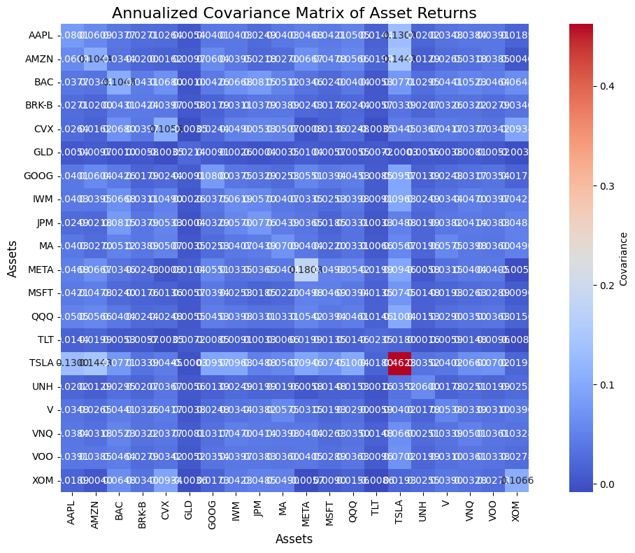

```python
import seaborn as sns
import matplotlib.pyplot as plt

# Plot the annualized covariance matrix as a heatmap
plt.figure(figsize=(12, 8))
sns.heatmap(cov_matrix, annot=True, cmap='coolwarm', fmt=".4f",
            xticklabels=cov_matrix.columns, yticklabels=cov_matrix.columns,
            cbar_kws={'label': 'Covariance'}, square=True)

# Title and labels
plt.title('Annualized Covariance Matrix of Asset Returns', fontsize=16)
plt.xlabel('Assets', fontsize=12)
plt.ylabel('Assets', fontsize=12)

# Show the plot
plt.tight_layout()
plt.show()
```

```python
# Calculate annualized volatility (standard deviation)
sigma = returns.std() * np.sqrt(12)

# Display the results (rounded to 4 decimal places)
print(round(sigma, 4))
```

```
Ticker
AAPL     0.2830
AMZN     0.3231
BAC      0.3234
BRK-B    0.2060
CVX      0.3250
GLD      0.1464
GOOG     0.2828
IWM      0.2487
JPM      0.2786
MA       0.2662
META     0.4253
MSFT     0.2165
QQQ      0.2147
TLT      0.1532
TSLA     0.6799
UNH      0.2449
V        0.2320
VNQ      0.2238
VOO      0.1840
XOM      0.3264
dtype: float64
```

# MV (Minimun Vairiance) Model

```
Minimum Variance Portfolio Weights:
AAPL: 0.0
AMZN: 0.0
BAC: 0.0
BRK-B: 0.0
CVX: 0.0
GLD: 0.3878
GOOG: 0.0
IWM: 0.0
JPM: 0.0277
MA: 0.0
META: 0.0
MSFT: 0.0279
QQQ: 0.0
TLT: 0.3664
TSLA: 0.0
UNH: 0.0752
V: 0.002
VNQ: 0.0
VOO: 0.0
XOM: 0.113

Minimum Variance Portfolio Expected Return: 0.0052
Minimum Variance Portfolio Volatility: 0.0304
```

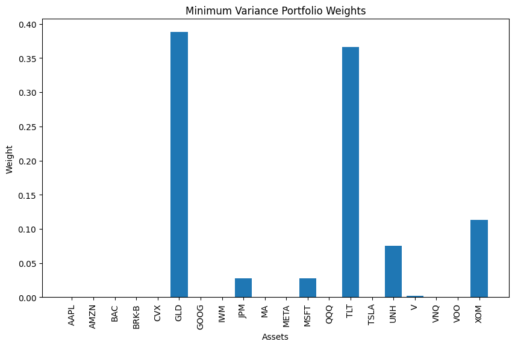

```python
# Calculate mean returns
mu = returns.mean()

# Calculate covariance matrix
cov = returns.cov()

# Number of assets
n = len(mu)

# Function to calculate portfolio volatility (risk)
def portfolio_volatility(weights, cov_matrix):
    return np.sqrt(np.dot(weights.T, np.dot(cov_matrix, weights)))

# Constraints: sum of weights must equal 1 (fully invested portfolio)
def constraint(weights):
    return np.sum(weights) - 1

# Initial guess (equal weights for all assets)
initial_weights = np.ones(n) / n

# Bounds for each weight (0 to 1 for each asset)
bounds = tuple((0, 1) for asset in range(n))

# Optimization to minimize portfolio volatility
opt_results = sco.minimize(portfolio_volatility, initial_weights, args=(cov,), method='SLSQP',
                           bounds=bounds, constraints={'type': 'eq', 'fun': constraint})

# Optimal weights for the minimum variance portfolio
min_variance_weights = opt_results.x

# Minimum variance portfolio volatility (risk)
min_variance_volatility = opt_results.fun

# Minimum variance portfolio return
min_variance_return = np.sum(min_variance_weights * mu)

# Display results
print("Minimum Variance Portfolio Weights:")
for i, ticker in enumerate(returns.columns):
    print(f"{ticker}: {round(min_variance_weights[i], 4)}")

print(f"\nMinimum Variance Portfolio Expected Return: {round(min_variance_return, 4)}")
print(f"Minimum Variance Portfolio Volatility: {round(min_variance_volatility, 4)}")

# Plot the minimum variance portfolio weights
plt.figure(figsize=(10, 6))
plt.bar(returns.columns, min_variance_weights)
plt.title('Minimum Variance Portfolio Weights')
plt.xlabel('Assets')
plt.ylabel('Weight')
plt.xticks(rotation=90)
plt.show()
```

# Conclusions from the Minimum Variance Portfolio (MVP) Model:

Low-Risk Focus: The model aims to minimize portfolio volatility by selecting assets that reduce overall risk, not necessarily maximizing return.

Heavy Weight on Defensive Assets: The portfolio is heavily weighted in GLD (Gold) and TLT (Long-Term Treasuries), which are traditionally considered safer, stable assets. These assets act as hedges against market downturns.

Minimal Exposure to High-Risk Assets: Major equities like AAPL, AMZN, and TSLA have zero or minimal weight, suggesting the model avoids assets with higher potential volatility.

Limited Diversification: Despite analyzing 20 assets, the model concentrates on a few low-risk assets, resulting in less diversification compared to more aggressive portfolios.

Defensive Asset Preference: The model prefers fixed-income (TLT) and precious metals (GLD), as they tend to perform better during periods of market stress, reducing overall portfolio risk.

Stability Over Growth: The MVP prioritizes capital preservation over high returns, making it suitable for risk-averse investors seeking stability, rather than growth.

Non-Efficient Portfolio: This is not an efficient portfolio in terms of the efficient frontier since it is only focused on reducing risk. It doesn't take into account the trade-off between risk and return needed for maximum returns at given risk levels.

Purpose: The MVP model is mainly designed to minimize risk, rather than achieve optimal returns for a given level of risk. Therefore, it is a conservative approach that reduces volatility, but sacrifices potential return.

# Create the Efficient Frontier

The Efficient Frontier (EF) is a fundamental concept in Modern Portfolio Theory (MPT), representing a set of optimal portfolios that provide the highest expected return for a given level of risk, or alternatively, the least risk for a given level of expected return.

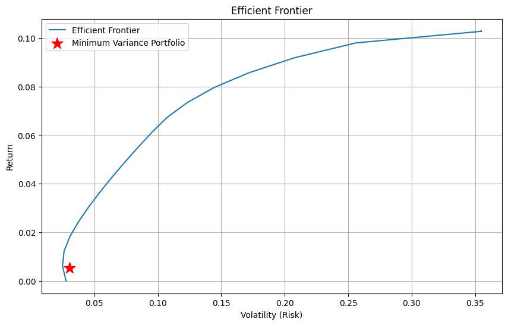

```python
# Function to calculate portfolio return
def portfolio_return(weights, mean_returns):
    return np.sum(weights * mean_returns)

# Function to calculate portfolio volatility (risk)
def portfolio_volatility(weights, cov_matrix):
    return np.sqrt(np.dot(weights.T, np.dot(cov_matrix, weights)))

# Function to calculate Sharpe Ratio
def sharpe_ratio(weights, mean_returns, cov_matrix, risk_free_rate=0.0):
    p_ret = portfolio_return(weights, mean_returns)
    p_vol = portfolio_volatility(weights, cov_matrix)
    return (p_ret - risk_free_rate) / p_vol

# Function to calculate the negative of the portfolio volatility
def neg_volatility(weights, mean_returns, cov_matrix):
    return portfolio_volatility(weights, cov_matrix)

# Constraints: sum of weights must equal 1
def constraint(weights):
    return np.sum(weights) - 1

# Target Return: 25% (0.25)
target_return = 0.25

# Number of assets
n = len(mu)

# Bounds for each weight (allowing negative weights for short-selling)
bounds = tuple((-1, 1) for asset in range(n))

# Initialize a list to store efficient portfolios
efficient_portfolios = []

# Loop over a range of target returns to find the efficient frontier
for target in np.linspace(0, 0.3, 50):  # Create portfolios for different target returns
    constraints = [{'type': 'eq', 'fun': constraint}, {'type': 'eq', 'fun': lambda w: portfolio_return(w, mu) - target}]
    initial_weights = np.ones(n) / n
    opt_results = sco.minimize(neg_volatility, initial_weights, args=(mu, cov), method='SLSQP',
                               bounds=bounds, constraints=constraints)
    efficient_portfolios.append(opt_results.x)

# Calculate the portfolio returns and volatilities for the efficient frontier
returns = [portfolio_return(w, mu) for w in efficient_portfolios]
volatilities = [portfolio_volatility(w, cov) for w in efficient_portfolios]

# Plot the Efficient Frontier
plt.figure(figsize=(10, 6))
plt.plot(volatilities, returns, label='Efficient Frontier')
plt.title('Efficient Frontier')
plt.xlabel('Volatility (Risk)')
plt.ylabel('Return')
plt.scatter(min_variance_volatility, min_variance_return, color='red', marker='*', s=200, label="Minimum Variance Portfolio")
plt.legend(loc='upper left')
plt.grid(True)
plt.show()
```

```python
import scipy.optimize as sco

# Function to calculate portfolio volatility (our objective function to minimize)
def portfolio_volatility(weights, cov_matrix):
    return np.sqrt(np.dot(weights.T, np.dot(cov_matrix, weights)))

# Constraint: the sum of weights must be 1 (fully invested portfolio)
def weight_sum_constraint(weights):
    return np.sum(weights) - 1

# Constraint: the expected return must match the target return
def return_constraint(weights, expected_returns, target_return):
    return np.dot(weights, expected_returns) - target_return
```

```python
# Annualized expected returns and covariance matrix
mu = returns.mean() * 12
cov = returns.cov() * 12

# Number of assets
n_assets = len(mu)

# Initial guess: equally distributed weights
initial_weights = np.ones(n_assets) / n_assets

# Bounds for weights: no short selling (weights between 0 and 1)
bounds = tuple((0, 1) for _ in range(n_assets))

# Define target expected return
target_return = 0.28  # Example: 15%
```

```python
# Define constraints
constraints = (
    {'type': 'eq', 'fun': weight_sum_constraint},
    {'type': 'eq', 'fun': return_constraint, 'args': (mu, target_return)}
)

# Perform the optimization
optimal = sco.minimize(portfolio_volatility,
                       initial_weights,
                       args=(cov,),
                       method='SLSQP',
                       bounds=bounds,
                       constraints=constraints)

# Extract optimal weights
optimal_weights = optimal.x
```

```python
# Display the optimal portfolio weights
optimal_portfolio = pd.Series(optimal_weights, index=mu.index)
print(round(optimal_portfolio, 4))

# Calculate expected return and volatility of the optimal portfolio
expected_return = np.dot(optimal_weights, mu)
expected_volatility = portfolio_volatility(optimal_weights, cov)

print(f"Expected Return: {expected_return:.4f}")
print(f"Expected Volatility: {expected_volatility:.4f}")
```

```
Ticker
AAPL     0.0000
AMZN     0.0000
BAC      0.0000
BRK-B    0.3402
CVX      0.0000
GLD      0.0241
GOOG     0.0000
IWM      0.0000
JPM      0.0000
MA       0.0000
META     0.0390
MSFT     0.0000
QQQ      0.0000
TLT      0.0000
TSLA     0.5921
UNH      0.0000
V        0.0000
VNQ      0.0000
VOO      0.0000
XOM      0.0046
dtype: float64
Expected Return: 0.2800
Expected Volatility: 0.4316
```

🔵 Key takeaways: